# Estructuras de control en R

Esteban Arroyo

25-11-2025

Las estructuras de control permiten controlar la manera o forma en que se ejecuta un determinado código.

Las estructuras de control establecen condiciones sobre el código. Por ejemplo, qué condiciones deben cumplirse para realizar una operación o qué debe ocurrir para ejecutar una función.

[figure not shown]

Esto es de gran utilidad para determinar la lógica y el orden en que ocurren las operaciones, en especial al definir funciones.

Por lo general son estructuras de código condicionales o iterativas (ciclos, bucles)

Las estructuras de control más usadas en R son las siguientes:

| **Estructura de Control** | **Descripción** |
| --- | --- |
| if, else | Si, de otro modo |
| for | Para cada uno en |
| while | Mientras |
| break | Interrupción |
| next | Siguiente |
| switch | Opera según valor |

### 1.- if, else

El if(), es usado cuando deseamos que una operación se ejecute únicamente cuando una condición se cumple.

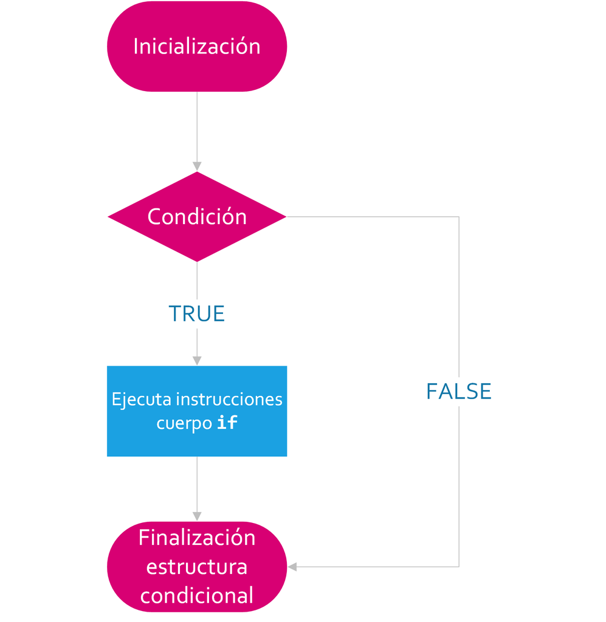

Por ejemplo:

```r
if(4 > 3){
  print("4 es mayor que 3")
}
```

```
[1] "4 es mayor que 3"
```

Por su parte el “else” se usa para complementar al if. Indica qué ocurrirá cuando la condición no se cumple

por ejemplo:

```r
if(4 > 5){
  print("4 es mayor que 5")
}else{
  print("4 es menor que 5")
}
```

```
[1] "4 es menor que 5"
```

Sin embargo, no se puede usar el “if” para recorrer un vector, porque sólo se usará el primer elemento del vector para evaluar si la condición es verdadera y lo demás será ignorado.

Por ejemplo si usamos este condicional para que indique cuales valores de un vector son menores de 4:

```r
if(1:10 < 4){
  print("Verdadero")
}
```

Esto quiere decir, que no podemos ejecutar el if() para todos y cada uno de los valores de un vector. Para corregir esto, usamos el ifelse(), que se usa para recorrer un vector según una condición.

```r
ifelse(1:10 < 4, TRUE, FALSE)
```

```
 [1]  TRUE  TRUE  TRUE FALSE FALSE FALSE FALSE FALSE FALSE FALSE
```

Aquí vemos cómo aparece el valor de TRUE en cada uno de los valores hasta el 3, de ahí en adelante, aparece un FALSE, porque no se cumple la condición

### 2.- FOR

La estructura “for” permite ejecutar un bucle (loop), realizando una operación para cada elemento de un conjunto de datos.

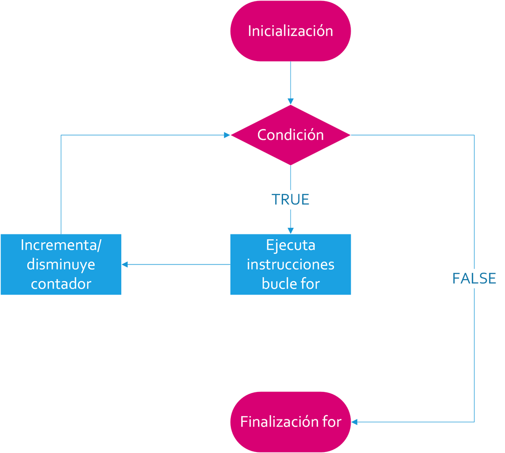

La estructura base es:

```r
for(elemento in objeto){
  operación con el elemento
}
```

Esto quiere decir que: **PARA** cada elemento **EN** el objeto, haz la siguiente operación.

El elemento dentro del paréntesis se puede llamar de cualquier forma, por ejemplo, le podemos llamar “i” o hacer alusión a los elementos dentro de un vector, por ejemplo “fruta” si el vector es de frutas, pero el nombre del vector u objeto, debe ser exactamente el mismo nombre.

Ejemplo simple recorriendo un vector

```r
for(i in 1:5){
   print(i)
}
```

```
[1] 1
[1] 2
[1] 3
[1] 4
[1] 5
```

Vemos que este código lo que hace es que recorre cada elemento del vector y lo imprime.

Ahora vamos a crear otro vector y luego usando el for(), vamnos a recorrerlo y a cada elemento le sumamos 1.

```r
objeto <- 1:5  # vector con los números de 1 al 5

for(elemento in objeto){
  print(elemento+1)  #imprimirá en consola a cada elemento del vector sumado a 1
}
```

```
[1] 2
[1] 3
[1] 4
[1] 5
[1] 6
```

Observe que hemos cambiado el índice “i” por “elemento”, y el código se ejecuta de igual manera

Esto hace exactamente lo mismo si nombramos al índice “a”

```r
for(a in objeto){
  print(a+1)
}
```

```
[1] 2
[1] 3
[1] 4
[1] 5
[1] 6
```

Lo importante es mantener la coherencia dentro del código.

Si nos interesa guardar el resultado de un for, lo podemos vectorizar en otro objeto:

```r
vector <- NULL   #Creamos un vector vacío
```

Luego ejecutamos el for donde decimos que cada resultado sea guardo en el vector usando las reglas de la indexación:

```r
for(i in objeto){
  vector[i]<- i+1 #cada valor del objeto se le suma 1 y se guarda en el vector iniciando en el indice i, que en este caso será el 1
}
```

Verificamos el resultado del vector

```r
vector
```

```
[1] 2 3 4 5 6
```

### 3.- while

Este es un tipo de bucle que ocurre mientras una condición es verdadera (TRUE). La operación se realiza hasta que se llega a cumplir un criterio previamente establecido.

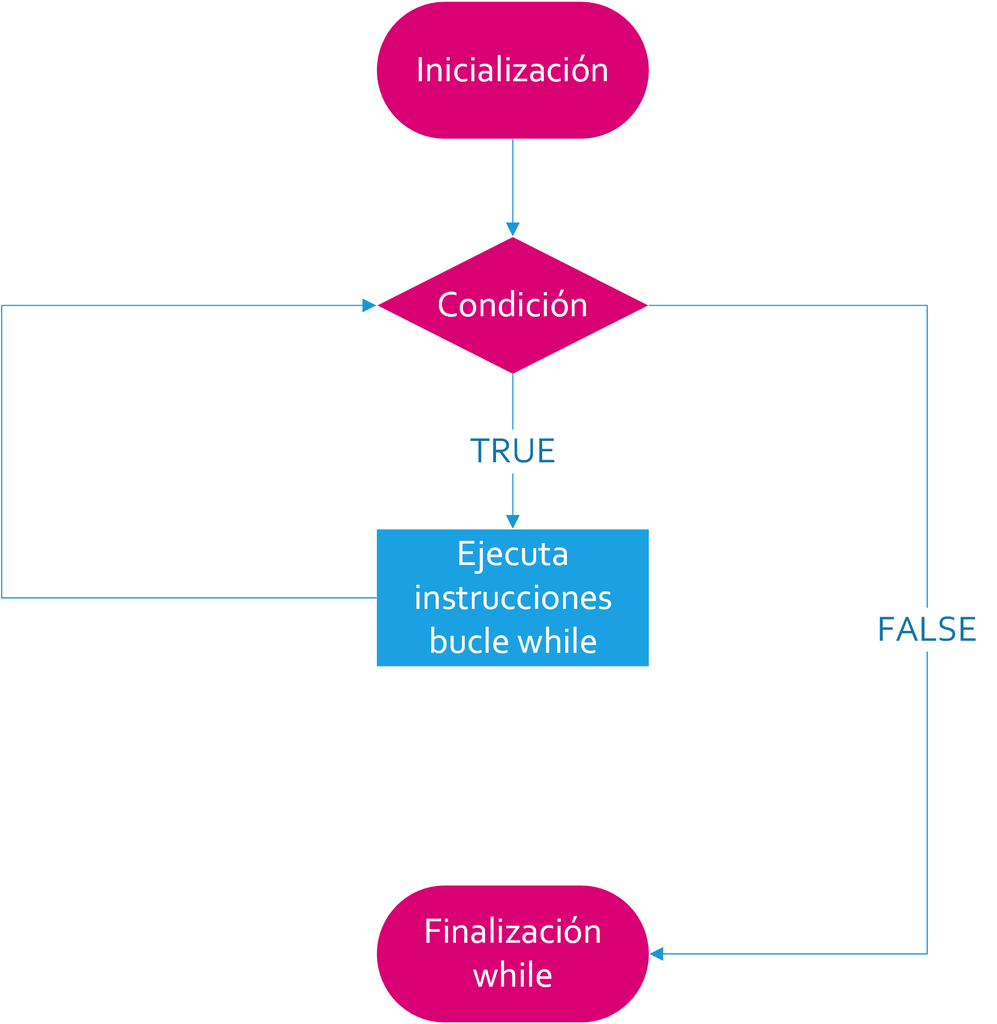

La estructura base del while es:

```r
while(condicion) {
  operaciones
}
```

Esto quiere decir que: **MIENTRAS** esta condición sea **VERDADERA**, realiza estas operaciones.

Ejemplo:

```r
#Definimos dos objetos. Uno con un valor de 5 y otro con valor 0

umbral <- 5
valor <- 0

#Aplicamos el while
while(valor < umbral) {    #establecemos la condición
  print("Todavía no.")     #se imprime este mensaje si se cumple la condición
  valor <- valor + 1       #En cada ciclo sumamos 1 al valor
}
```

```
[1] "Todavía no."
[1] "Todavía no."
[1] "Todavía no."
[1] "Todavía no."
[1] "Todavía no."
```

Este código imprimirá en la consola el texto “Todavía no.” mientras el objeto “valor” sea menor que el “umbral” (esto porque en cada ciclo valor se aumenta en 1). Una vez que el objeto valor sea mayor que umbral, se detiene el proceso. Se observa que en cada ciclo se suma +1 al valor actual de valor y esa suma se guarda en el mismo objeto: valor <- valor + 1, es decir, en el 1er ciclo valor es igual a 0 , pero le estamos sumando 1, entonces, cuando empieza el 2do ciclo, valor es igual a 1 y así sigue hasta que valor llegue a 5.

Si no, se agrega esta instrucción: valor <- valor + 1, se creará un bucle infinito. Solo se puede detener presionando la tecla ESC, de otro modo, correrá por siempre y puede llegar a congelar el equipo.

Veamos otro ejemplo:

```r
x <- 1
while(x <=5){
  print(x)
  x <- x+1
}
```

```
[1] 1
[1] 2
[1] 3
[1] 4
[1] 5
```

Aquí se va a imprimir el valor de x hasta que este sea menor o igual a 5.

### 4.- break y next

break y next son palabras reservadas en R, no se puede asignarles nuevos valores y realizan una operación específica cuando aparecen o se usan en el código. Ambas funcionan para for y while, pero dentro de un if() anidado.

- break permite interrumpir un bucle.
- next permite avanzar a la siguiente iteración del bucle, “saltándose” la actual.

**Usando break**

Para interrumpir un bucle con break, necesitamos que se cumpla una condición. Cuando esto ocurre, el bucle se detiene, aunque existan elementos a los cuales aún podría aplicarse.

Por ejemplo:

Interrumpimos un for cuando i es igual a 3, aunque aún queden 7 elementos en el objeto.

```r
for(i in 1:10){
  if(i==3){
    print("Aquí se detiene")
    break   #implementamos la interrupción
  }
  print(i)  #vamos imprimiendo los valores del vector
}
```

```
[1] 1
[1] 2
[1] "Aquí se detiene"
```

Observamos que se imprime el 1 y 2 , pero donde debía estar el 3, se imprimió el mensaje “Aquí se detiene” y se detuvo el ciclo.

Para interrumpir un while antes de se cumpla la condición lo vemos en el siguiente ejemplo: implementamos la condición que un numero sea mayor a 5, y cuando este tenga el valor de 15, se detiene.

```r
numero <- 20  #definimos un objeto con el valor de 20

while (numero >5) {
  if(numero==15){
    print(paste("Se detiene cuando es igual a", numero))
    break #implementamos la interrupción
  }
  print(numero) #vamos imprimiendo los valores del vector
  numero <- numero-1  #Le vamos restando un 1 en cada ciclo. Recuerden que comenzamos en 20
}
```

```
[1] 20
[1] 19
[1] 18
[1] 17
[1] 16
[1] "Se detiene cuando es igual a 15"
```

Esta es otra forma de hacerlo, pero en lugar de inicializar el objeto “numero” en 20 e ir restando en cada ciclo, inicializamos en 6 (porque la condición es que sea mayor a 5), y vamos sumando 1 en cada ciclo.

```r
numero <- 6

while(numero >5){
  if(numero==15){
    break
  }
  print(numero)
  numero <- numero+1
}
```

```
[1] 6
[1] 7
[1] 8
[1] 9
[1] 10
[1] 11
[1] 12
[1] 13
[1] 14
```

**Usando next**

Se usa “next” para “saltarnos” una iteración en un bucle. Cuando la condición se cumple, esa iteración es omitida.

Por ejemplo:

```r
for(i in 1:5){
  if(i==3){
    print("Se ha saltado el número 3")
    next   #implementamos el salto
  }
  print(i)  #vamos imprimiendo los valores del vector
}
```

```
[1] 1
[1] 2
[1] "Se ha saltado el número 3"
[1] 4
[1] 5
```

Este es lo mismo, pero implementado en un while

```r
x <- 0                 #Creamos un objeto con el valor 0
while(x <5){           #la condición es que x sea menor a 5
  x <- x+1             #implementamos la suma de 1 en cada ciclo
  if(x==3){
    print("Se ha saltado el número 3")  #Mostramos mensaje en cónsola
    next                                #implementamos el salto
  }
  print(x)              #vamos imprimiendo los valores del vector
}
```

```
[1] 1
[1] 2
[1] "Se ha saltado el número 3"
[1] 4
[1] 5
```

### 5.- switch

En líneas generales, esta estructura de control ejecuta una acción o bloque de código según el valor de un objeto o variable. Es una alternativa al uso de múltiples sentencias if-else anidadas.

La función switch evalúa un índice o una cadena de texto y elige una opción entre una lista de alternativas.

La función switch toma como entrada un objeto que puede ser un número o una cadena de caracteres y una lista de alternativas.

Por ejemplo:

```r
valor <- 1  #definimos un objeto con un número 1

#implelemtamos el switch
switch (valor,             #Aquí recoge el valor del objeto
  "Primera acción",        #primera alternativa si el valor es igual a 1
  "Segunda acción",        #segunda alternativa si el valor es igual a 2
  "Tercera acción"         #tercera alternativa si el valor es igual a 3
)
```

```
[1] "Primera acción"
```

Como valor es igual a 1 es resultado es “Primera acción”. Si cambiamos el valor 2 o 3, el resultado también cambiará de acuerdo a las alternativas dispuestas en el switch.

Otro ejemplo un poco más complejo puede ser la operación matemática de dos valores: Si seleccionamos “s” se realizará la suma, si seleccionamos “r”, realizaremos una resta y si seleccionamos “m”, haremos una multiplicación.

```r
# Definimos dos objetos numéricos para poder operar
valor1 <- 4
valor2 <- 2

# Definimos un objeto que sirva de selección de alternativas
opcion <- "s"

#implelemtamos el switch
switch (opcion,
  "s" = paste("Suma:", valor1+valor2),
  "r" = paste("Resta:", valor1-valor2),
  "m"= paste("Multiplicación:",valor1*valor2)
)
```

```
[1] "Suma: 6"
```

Como opción es igual a “s”, el resultado es: “Suma: 6”

### EXTRA: Conjunto de Funciones apply

La familia apply pertenece al paquete base R y esta formado por un conjunto de funciones que nos permiten manipular una selección de elementos en matrices, arrays, listas y dataframes de forma repetitiva.

Estas funciones nos permiten iterar por los elementos sin tener la necesidad de utilizar explícitamente una función iterativa.

Toman como entrada una lista, matriz o vector y aplican esta función a cada elemento

La familia apply esta compuesta de las funciones:

- apply
- lapply
- sapply
- vapply
- mapply
- rapply
- tapply

**Función apply()**

Es una herramienta que permite aplicar una función (como sum, mean, min, max, etc), a las filas o columnas de una matriz o data frame, evitando los bucles como el **for**.

Los argumentos que necesita la función son estos:

- **X**: La matriz o data frame a la que se aplicará la función.
- **MARGIN**: Un número que indica la dirección de la operación: 1: Aplica la función a cada fila. 2: Aplica la función a cada columna.
- **FUN**: La función que se ejecutará. Se escribe el nombre de la función sin paréntesis, ya que apply() se encargará de los argumentos.

Por ejemplo, si tenemos el siguiente dataframe:

```r
df = data.frame("sexo"=c("fem", "mas",  "fem",  "mas",  "mas",  "fem"),
                "edad"=c(30, 18, 20, 21, 20, 30),
                "ingreso"=c(289, 295.5, 290.2, 292,  298, 284.8),
                "gastos"=c(15.4, 14.5, 16.2, 15.9,  16.6, 14.8))
```

Queremos sumar los valores de las columnas edad, ingreso y gastos:

```r
apply(df[,2:4], 2, sum)   #indicamos por indexación que solo necesitamos las columnas de la 2 a 4
```

```
   edad ingreso  gastos
  139.0  1749.5    93.4
```

Ahora queremos el promedio o media de las mismas columnas

```r
apply(df[,2:4], 2, mean)
```

```
     edad   ingreso    gastos
 23.16667 291.58333  15.56667
```

**Función lapply()**

Aplica una función sobre una lista o vector, evitando el uso de bucles.

```r
#Creamos la siguiente lista con los siguientes vectores
x <- list(a = 1:10, b = runif(10), c = rnorm(n = 10, mean = 50, sd = 5))

# APlicamos el promedio de cada uno de los vectores
lapply(x, mean)
```

```
$a
[1] 5.5

$b
[1] 0.3903538

$c
[1] 48.84096
```

**Función sapply()**

Es una versión del lapply, pero con una forma más “amigable” de presentar los resultados

```r
#con los mismos datos de la lista "x"

sapply(x, mean)
```

```
         a          b          c
 5.5000000  0.3903538 48.8409584
```

Por ejemplo si queremos ver los “cuartiles”, los presenta de esta forma:

```r
sapply(x, quantile)
```

```
         a          b        c
0%    1.00 0.02102869 40.57076
25%   3.25 0.27930674 44.76628
50%   5.50 0.42746133 48.90864
75%   7.75 0.51307318 53.63989
100% 10.00 0.75948376 58.56755
```

Mientras que si usamos lapply, los presenta de esta forma:

```r
lapply(x, quantile)
```

```
$a
   0%   25%   50%   75%  100%
 1.00  3.25  5.50  7.75 10.00

$b
        0%        25%        50%        75%       100%
0.02102869 0.27930674 0.42746133 0.51307318 0.75948376

$c
      0%      25%      50%      75%     100%
40.57076 44.76628 48.90864 53.63989 58.56755
```